# INFO250 Final Project - COVID 19 India

## INFO 250: Final Project

By: Nathan Beebe, Surya Ramanathan, Asma Khatut

In the 2021 COVID 19 pandemic, it is important to understand how regions have been affected by the region. Data visualization is an important tool that allow us to quickly communicate how the different regions of India have been affected as of August 2021.

# Heatmap

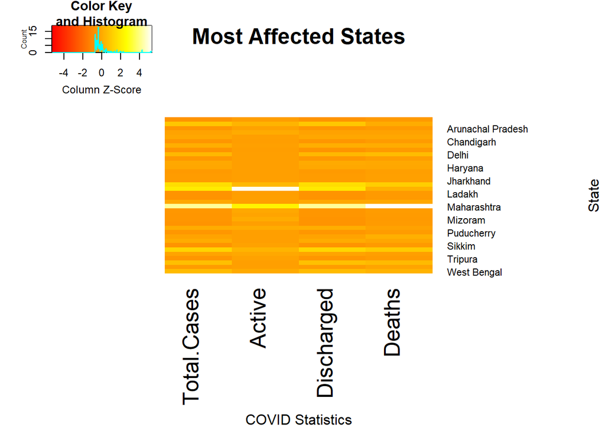

# Barchart

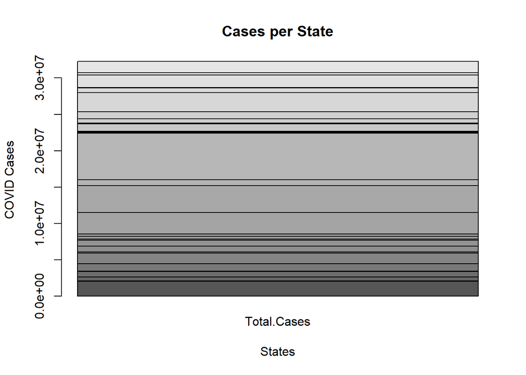

This barchart showcases the total number of cases per state. Each bar that is in a shade of gray on the X-axis represents each Indian state. Then the numerical count of the COVID-19 cases is measured on the Y-axis. According to the data, 20 of the 36 states are in the range of having 7500-650000 cases. Another 8 states had about 650000-1300000 cases. The next 3 more were nearing 2000000. Then the remaining 5 states were in the range of having around 2000000-6500000.

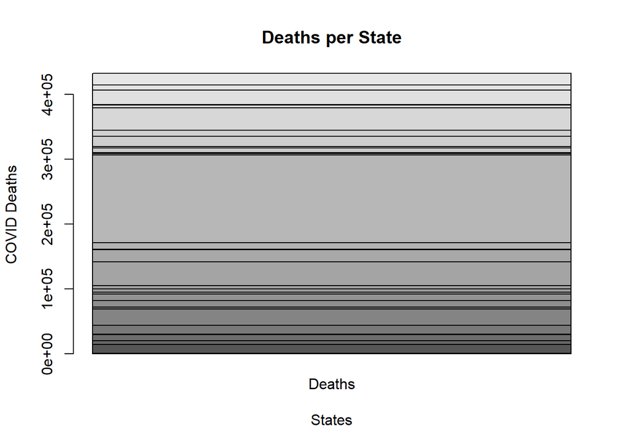

# Multi-set Barchart

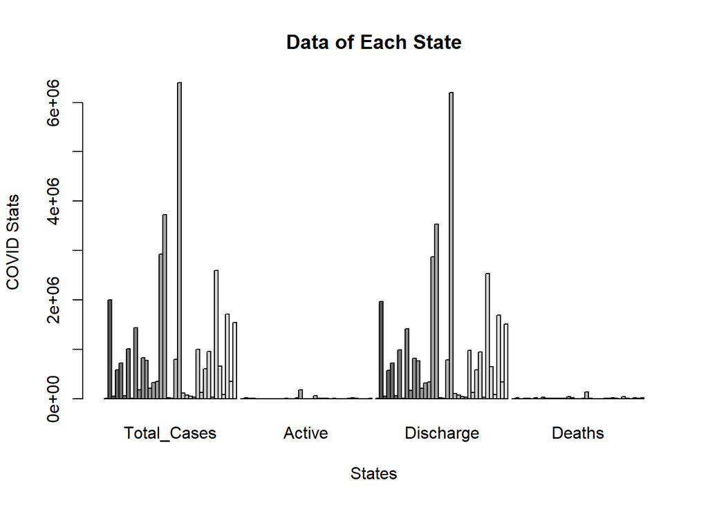

This chart shows different cases in every state of India. Each set shows the stats for the certain case in each state. The x-axis represents the different sets of cases, each set has multiple bars that represent the states in India. The y-axis represents the COVID Stats for those cases. Each bar in a set is a different shade of grey, with each one representing a different state. The same shade of grey in the four sets would represent the same state but a different case.

According to the graph, overall, the number of discharge cases are more than the active cases and death cases. For instance, the state with the least active cases has a total number of 1 cases and the state with the least death cases has a total number of 4, while the state with the least number of discharge cases has a total number of 7,419 cases. The state with the most active cases has a total number of 175,695 cases and the state with the most death cases has a total of 135255 cases, while the state with the highest discharge cases has a total of 6,201,168 cases.